# Quiz4

mail@darrenbishop.com

26 March 2016

```r
library(knitr)
library(ggplot2)
library(ggdendro)
library(gridExtra)
library(rpart.plot)
library(Hmisc)
library(caret)

opts_chunk$set(message=FALSE, warning = FALSE, fig.path="figures/", fig.width=10, fig.align = "center")
```

## Question 1

> Load the vowel.train and vowel.test data sets:

```r
library(ElemStatLearn)

data(vowel.train)
data(vowel.test)
```

> Set the variable y to be a factor variable in both the training and test set. Then set the seed to 33833. Fit (1) a random forest predictor relating the factor variable y to the remaining variables and (2) a boosted predictor using the “gbm” method. Fit these both with the train() command in the caret package.

```r
vowel.train$y = as.factor(vowel.train$y)
vowel.test$y = as.factor(vowel.test$y)

vowel.data = rbind(vowel.train, vowel.test)

set.seed(33833)
# rfModel = randomForest(y ~ ., data = vowel.train, proximity = TRUE)
rfModel = train(y ~ ., data = vowel.train, method = "rf", proximity = TRUE)
gbmModel = train(y ~ ., data = vowel.train, method = "gbm", verbose = FALSE)
```

> What are the accuracies for the two approaches on the test data set? What is the accuracy among the test set samples where the two methods agree?

```r
rfPred = predict(rfModel, newdata = vowel.test)
gbmPred = predict(gbmModel, newdata = vowel.test)

confusionMatrix(rfPred, vowel.test$y)
```

```
## Confusion Matrix and Statistics
##
##           Reference
## Prediction  1  2  3  4  5  6  7  8  9 10 11
##         1  34  3  0  0  0  0  0  0  0  1  0
##         2   7 21  3  0  0  0  0  0  1 13  1
##         3   1 14 32  3  0  1  0  0  0  5  2
##         4   0  0  2 29  3  0  0  0  0  0  2
##         5   0  0  0  0 20  8  8  0  0  0  0
##         6   0  0  4  9 15 22  3  0  0  0  5
##         7   0  0  0  0  3  0 28  6  5  0  3
##         8   0  0  0  0  0  0  0 32  6  0  0
##         9   0  4  0  0  0  0  2  4 23  1 11
##         10  0  0  0  0  0  0  1  0  2 22  0
##         11  0  0  1  1  1 11  0  0  5  0 18
##
## Overall Statistics
##
##                Accuracy : 0.6082
##                  95% CI : (0.5621, 0.653)
##     No Information Rate : 0.0909
##     P-Value [Acc > NIR] : < 2.2e-16
##
##                   Kappa : 0.569
##  Mcnemar's Test P-Value : NA
##
## Statistics by Class:
##
##                      Class: 1 Class: 2 Class: 3 Class: 4 Class: 5 Class: 6
## Sensitivity           0.80952  0.50000  0.76190  0.69048  0.47619  0.52381
## Specificity           0.99048  0.94048  0.93810  0.98333  0.96190  0.91429
## Pos Pred Value        0.89474  0.45652  0.55172  0.80556  0.55556  0.37931
## Neg Pred Value        0.98113  0.94952  0.97525  0.96948  0.94836  0.95050
## Prevalence            0.09091  0.09091  0.09091  0.09091  0.09091  0.09091
## Detection Rate        0.07359  0.04545  0.06926  0.06277  0.04329  0.04762
## Detection Prevalence  0.08225  0.09957  0.12554  0.07792  0.07792  0.12554
## Balanced Accuracy     0.90000  0.72024  0.85000  0.83690  0.71905  0.71905
##                      Class: 7 Class: 8 Class: 9 Class: 10 Class: 11
## Sensitivity           0.66667  0.76190  0.54762   0.52381   0.42857
## Specificity           0.95952  0.98571  0.94762   0.99286   0.95476
## Pos Pred Value        0.62222  0.84211  0.51111   0.88000   0.48649
## Neg Pred Value        0.96643  0.97642  0.95444   0.95423   0.94353
## Prevalence            0.09091  0.09091  0.09091   0.09091   0.09091
## Detection Rate        0.06061  0.06926  0.04978   0.04762   0.03896
## Detection Prevalence  0.09740  0.08225  0.09740   0.05411   0.08009
## Balanced Accuracy     0.81310  0.87381  0.74762   0.75833   0.69167
```

```r
confusionMatrix(gbmPred, vowel.test$y)
```

```
## Confusion Matrix and Statistics
##
##           Reference
## Prediction  1  2  3  4  5  6  7  8  9 10 11
##         1  29  1  0  0  0  0  0  0  0  3  0
##         2  10 19  1  0  0  0  1  0  0 16  0
##         3   2 13 12  3  0  0  0  0  0  0  0
##         4   0  2 10 19  3  0  1  0  0  0  1
##         5   0  0  0  1 16  6  1  0  0  0  0
##         6   0  1 15 18 11 27  2  0  3  0 12
##         7   0  0  1  0  8  2 34  8  4  0 12
##         8   0  0  0  0  0  0  2 28  8  0  0
##         9   0  4  0  0  0  0  0  6 27  2 13
##         10  1  0  0  0  0  0  0  0  0 21  0
##         11  0  2  3  1  4  7  1  0  0  0  4
##
## Overall Statistics
##
##                Accuracy : 0.5108
##                  95% CI : (0.4642, 0.5573)
##     No Information Rate : 0.0909
##     P-Value [Acc > NIR] : < 2.2e-16
##
##                   Kappa : 0.4619
##  Mcnemar's Test P-Value : NA
##
## Statistics by Class:
##
##                      Class: 1 Class: 2 Class: 3 Class: 4 Class: 5 Class: 6
## Sensitivity           0.69048  0.45238  0.28571  0.45238  0.38095  0.64286
## Specificity           0.99048  0.93333  0.95714  0.95952  0.98095  0.85238
## Pos Pred Value        0.87879  0.40426  0.40000  0.52778  0.66667  0.30337
## Neg Pred Value        0.96970  0.94458  0.93056  0.94601  0.94064  0.95979
## Prevalence            0.09091  0.09091  0.09091  0.09091  0.09091  0.09091
## Detection Rate        0.06277  0.04113  0.02597  0.04113  0.03463  0.05844
## Detection Prevalence  0.07143  0.10173  0.06494  0.07792  0.05195  0.19264
## Balanced Accuracy     0.84048  0.69286  0.62143  0.70595  0.68095  0.74762
##                      Class: 7 Class: 8 Class: 9 Class: 10 Class: 11
## Sensitivity           0.80952  0.66667  0.64286   0.50000  0.095238
## Specificity           0.91667  0.97619  0.94048   0.99762  0.957143
## Pos Pred Value        0.49275  0.73684  0.51923   0.95455  0.181818
## Neg Pred Value        0.97964  0.96698  0.96341   0.95227  0.913636
## Prevalence            0.09091  0.09091  0.09091   0.09091  0.090909
## Detection Rate        0.07359  0.06061  0.05844   0.04545  0.008658
## Detection Prevalence  0.14935  0.08225  0.11255   0.04762  0.047619
## Balanced Accuracy     0.86310  0.82143  0.79167   0.74881  0.526190
```

```r
confusionMatrix(rfPred, gbmPred)
```

```
## Confusion Matrix and Statistics
##
##           Reference
## Prediction  1  2  3  4  5  6  7  8  9 10 11
##         1  27  6  2  0  0  0  0  0  0  2  1
##         2   3 37  3  0  0  1  0  0  0  0  2
##         3   3  0 25 10  0 13  3  0  1  2  1
##         4   0  0  0 23  0 12  0  0  0  0  1
##         5   0  0  0  0 18  3 14  1  0  0  0
##         6   0  0  0  0  5 46  4  0  0  0  3
##         7   0  1  0  0  1  0 40  1  1  0  1
##         8   0  0  0  0  0  0  2 34  2  0  0
##         9   0  0  0  2  0  3  1  2 37  0  0
##         10  0  3  0  0  0  0  1  0  3 18  0
##         11  0  0  0  1  0 11  4  0  8  0 13
##
## Overall Statistics
##
##                Accuracy : 0.6883
##                  95% CI : (0.6439, 0.7303)
##     No Information Rate : 0.1926
##     P-Value [Acc > NIR] : < 2.2e-16
##
##                   Kappa : 0.6548
##  Mcnemar's Test P-Value : NA
##
## Statistics by Class:
##
##                      Class: 1 Class: 2 Class: 3 Class: 4 Class: 5 Class: 6
## Sensitivity           0.81818  0.78723  0.83333  0.63889  0.75000  0.51685
## Specificity           0.97436  0.97831  0.92361  0.96948  0.95890  0.96783
## Pos Pred Value        0.71053  0.80435  0.43103  0.63889  0.50000  0.79310
## Neg Pred Value        0.98585  0.97596  0.98762  0.96948  0.98592  0.89356
## Prevalence            0.07143  0.10173  0.06494  0.07792  0.05195  0.19264
## Detection Rate        0.05844  0.08009  0.05411  0.04978  0.03896  0.09957
## Detection Prevalence  0.08225  0.09957  0.12554  0.07792  0.07792  0.12554
## Balanced Accuracy     0.89627  0.88277  0.87847  0.80419  0.85445  0.74234
##                      Class: 7 Class: 8 Class: 9 Class: 10 Class: 11
## Sensitivity           0.57971  0.89474  0.71154   0.81818   0.59091
## Specificity           0.98728  0.99057  0.98049   0.98409   0.94545
## Pos Pred Value        0.88889  0.89474  0.82222   0.72000   0.35135
## Neg Pred Value        0.93046  0.99057  0.96403   0.99085   0.97882
## Prevalence            0.14935  0.08225  0.11255   0.04762   0.04762
## Detection Rate        0.08658  0.07359  0.08009   0.03896   0.02814
## Detection Prevalence  0.09740  0.08225  0.09740   0.05411   0.08009
## Balanced Accuracy     0.78349  0.94265  0.84601   0.90114   0.76818
```

*Answer:*

> RF Accuracy = 0.6082

> Agreement Accuracy = 0.6361

### Question 2

> Load the Alzheimer’s data using the following commands

```r
library(caret)
library(gbm)
set.seed(3433)
library(AppliedPredictiveModeling)
data(AlzheimerDisease)
adData = data.frame(diagnosis,predictors)

inTrain = createDataPartition(adData$diagnosis, p = 3/4)[[1]]
training = adData[ inTrain,]
testing = adData[-inTrain,]
```

> Set the seed to 62433 and predict diagnosis with all the other variables using a random forest (“rf”), boosted trees (“gbm”) and linear discriminant analysis (“lda”) model. Stack the predictions together using random forests (“rf”). What is the resulting accuracy on the test set? Is it better or worse than each of the individual predictions?

```r
set.seed(62433)
# rfModel = train(diagnosis ~ ., data = training, method = "rf", number = 3, proximity = TRUE)
rf2Model = train(diagnosis ~ ., data = training, method = "rf", number = 3, trControl = trainControl(method = "cv"), proximity = TRUE)
gbmModel = train(diagnosis ~ ., data = training, method = "gbm", verbose = FALSE)
ldaModel = train(diagnosis ~ ., data = training, method = "lda", verbose = FALSE)

m.vote <- function(n, p) {
    m = n %/% 2 + 1
    terms = sapply(m:n, function(k) choose(n, k) * p^(k) * (1-p)^(n-k))
    sum(terms)
}

rfPred = predict(rf2Model, testing)
gbmPred = predict(gbmModel, testing)
ldaPred = predict(ldaModel, testing)

stackData = data.frame(rfPred, gbmPred, ldaPred, diagnosis = testing$diagnosis)

stackModel = train(diagnosis ~ ., data = stackData, method = "rf", number = 3, proximity = TRUE)
stackPred = predict(stackModel, testing)

confusionMatrix(rfPred, testing$diagnosis)$overall['Accuracy']
```

```
##  Accuracy
## 0.7926829
```

```r
confusionMatrix(gbmPred, testing$diagnosis)$overall['Accuracy']
```

```
##  Accuracy
## 0.7804878
```

```r
confusionMatrix(ldaPred, testing$diagnosis)$overall['Accuracy']
```

```
##  Accuracy
## 0.7682927
```

```r
confusionMatrix(stackPred, testing$diagnosis)$overall['Accuracy']
```

```
## Accuracy
## 0.804878
```

### Question 3

> Load the concrete data with the commands:

```r
set.seed(3523)
library(AppliedPredictiveModeling)
data(concrete)

inTrain = createDataPartition(concrete$CompressiveStrength, p = 3/4)[[1]]
training = concrete[ inTrain,]
testing = concrete[-inTrain,]
```

> Set the seed to 233 and fit a lasso model to predict Compressive Strength. Which variable is the last coefficient to be set to zero as the penalty increases? (Hint: it may be useful to look up ?plot.enet).

```r
set.seed(233)
model = train(CompressiveStrength ~ ., data = concrete, method = "lasso")
summary(model$finalModel)
```

```
##             Length Class      Mode
## call         4     -none-     call
## actions     11     -none-     list
## allset       8     -none-     numeric
## beta.pure   88     -none-     numeric
## vn           8     -none-     character
## mu           1     -none-     numeric
## normx        8     -none-     numeric
## meanx        8     -none-     numeric
## lambda       1     -none-     numeric
## L1norm      11     -none-     numeric
## penalty     11     -none-     numeric
## df          11     -none-     numeric
## Cp          11     -none-     numeric
## sigma2       1     -none-     numeric
## xNames       8     -none-     character
## problemType  1     -none-     character
## tuneValue    1     data.frame list
## obsLevels    1     -none-     logical
```

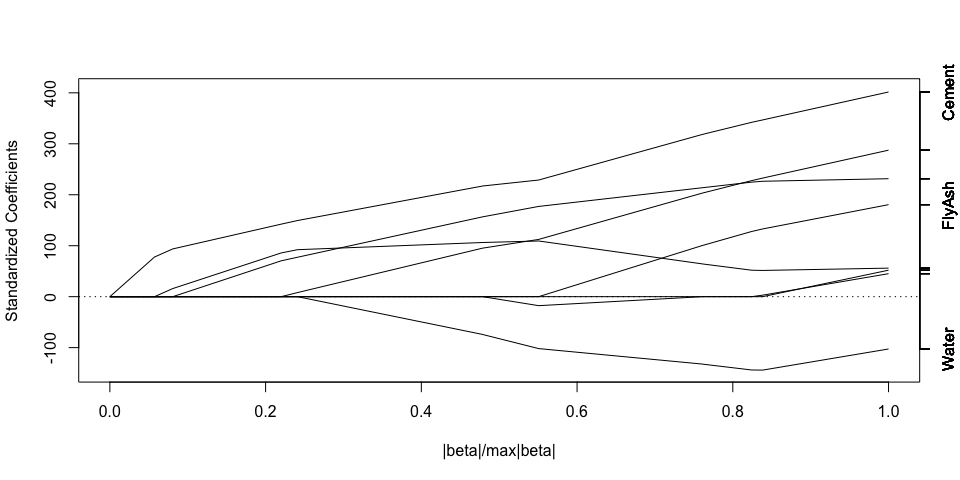

```r
plot(model$finalModel)
```

*Answer:*

> Cement

### Question 4

> Load the data on the number of visitors to the instructors blog from here:

```r
library(forecast)
library(lubridate) # For year() function below

if (!file.exists("gaData.csv")) {
    download.file("https://d396qusza40orc.cloudfront.net/predmachlearn/gaData.csv", destfile = "gaData.csv")
}
dat = read.csv("gaData.csv")

training = dat[year(dat$date) < 2012,]
testing = dat[year(dat$date) > 2011,]
tstrain = ts(training$visitsTumblr)
```

> Fit a model using the bats() function in the forecast package to the training time series. Then forecast this model for the remaining time points. For how many of the testing points is the true value within the 95% prediction interval bounds?

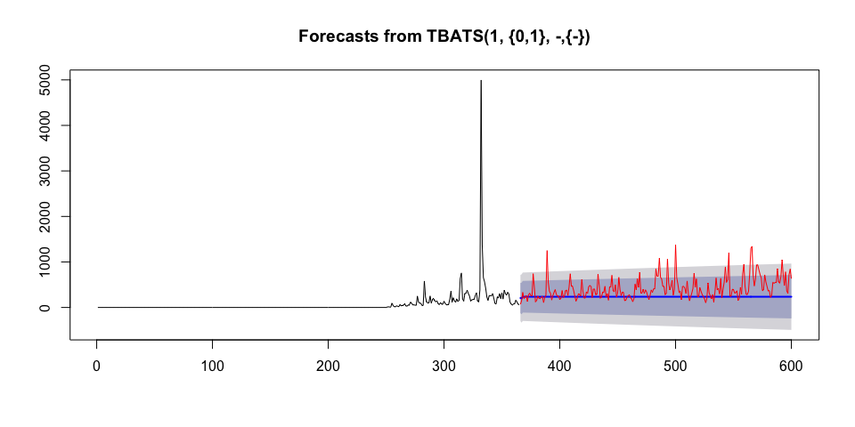

```r
tsmodel = bats(tstrain)
f = forecast(tsmodel, nrow(testing))
plot(f)
lines(ts(testing$visitsTumblr, start = 366), col= "red")
```

```r
accuracy(f, ts(testing$visitsTumblr, start = 366))
```

```
##                     ME     RMSE       MAE      MPE     MAPE      MASE
## Training set  10.39787 258.7813  40.22707     -Inf      Inf 0.8437138
## Test set     185.20149 301.2620 205.87807 26.06409 40.76475 4.3180420
##                   ACF1 Theil's U
## Training set 0.0121040        NA
## Test set     0.4751213  1.092536
```

*Answer:*

> 96%

### Question 5

> Load the concrete data with the commands:

```r
set.seed(3523)
library(AppliedPredictiveModeling)
data(concrete)

inTrain = createDataPartition(concrete$CompressiveStrength, p = 3/4)[[1]]
training = concrete[ inTrain,]
testing = concrete[-inTrain,]
```

> Set the seed to 325 and fit a support vector machine using the e1071 package to predict Compressive Strength using the default settings. Predict on the testing set. What is the RMSE?

```r
library(e1071)
set.seed(325)
model = svm(CompressiveStrength ~ ., data = training)
pred = predict(model, newdata = testing)
accuracy(pred, testing$CompressiveStrength)
```

```
##                 ME     RMSE      MAE       MPE     MAPE
## Test set 0.1682863 6.715009 5.120835 -7.102348 19.27739
```

*** Answer:***

> 6.715009

```r
library(quantmod)
from.dat = as.Date("01/01/08", format = "%m/%d/%y")
to.dat = as.Date("12/31/13", format = "%m/%d/%y")
getSymbols("GOOG", src = "google", from = from.dat, to = to.dat)
```

```
## [1] "GOOG"
```

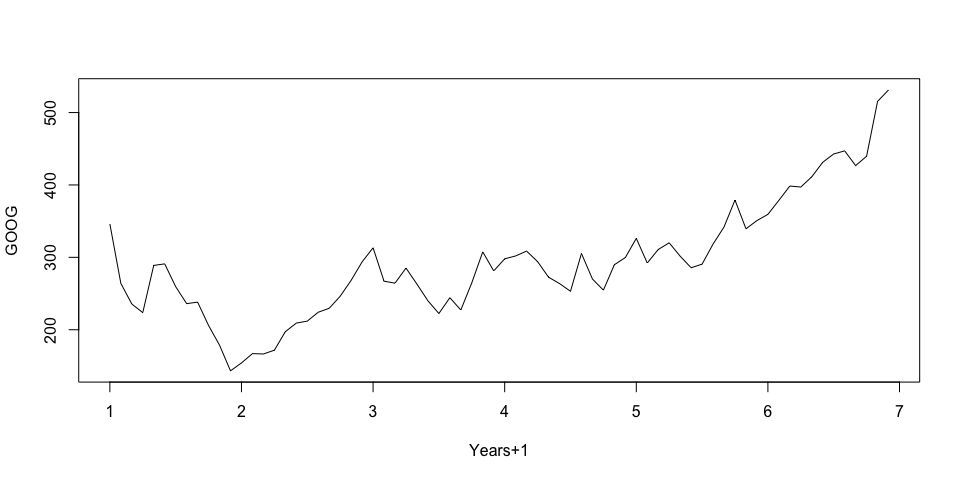

```r
mGoog = to.monthly(OHLC(GOOG))
googOpen = Op(mGoog)
tsGoog = ts(googOpen, frequency = 12)
plot(tsGoog, xlab = "Years+1", ylab = "GOOG")
```

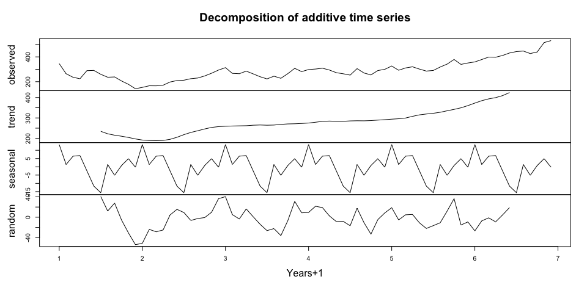

```r
plot(decompose(tsGoog), xlab="Years+1")
```